# Experimentation at Scale Challenges and Opportunities in A/B Testing

R Samyak

Bangalore Probability Seminar · 26 Oct 2026

## Disclaimer

Views expressed in this seminar are the speaker’s own, and do not necessarily represent any employer, past or present.

## Outline

Outline

Not a results talk, but an invitation.

Intro

A/B testing platforms

Problem 1

Speed vs accuracy

Problem 2

How many hypotheses

Problem 3

Measuring the methods

Industry has (ill-posed, open) problems, data, funding; Need expertise from academia

## Intro

Intro

A/B testing platforms

Problem 1

Speed vs accuracy

Problem 2

How many hypotheses

Problem 3

Measuring the methods

## Sample experiment: checkout page

[figure not shown]

Metric: Click-through rate / Revenue per user

## The textbook A/B test

- $Z_i$ is $A$ or $B$ with equal probability, and we observe $Y_i=Y_i(Z_i)$.
- $\theta=\mathbb{E}[Y_i(B)-Y_i(A)]$, over a random visitor. $\hat\theta=\bar Y_B-\bar Y_A$. Let $\mathcal X$ be the observed data.

$$\varphi(\mathcal X)=\begin{cases} B & \text{if }\hat\theta>1.96\operatorname{se}(\hat\theta),\\ A & \text{o.w.}\end{cases}
\qquad
\varphi^*(\theta)=\begin{cases} B & \text{if }\theta>0,\\ A & \text{o.w.}\end{cases}$$

- Guarantee. $\mathbb{P}(|\hat\theta|>1.96\operatorname{se}(\hat\theta))\approx0.05$ when $\theta=0$.

Jerzy Neyman 1923; Ronald Fisher 1935; Donald Rubin 1974.

## A sequential test

- Visitors arrive in order. $\mathcal X_t$ is the data up to time $t$, and $\hat\theta_t$ is its estimate.
- $\tau$ is a stopping time: $\{\tau=t\}$ is determined by $\mathcal X_t$. The observed sample is $\mathcal X=\mathcal X_\tau$.
- One example. Boundaries $b_t$, fixed in advance, up to a last time $n$.

$$\tau=\min\big(\{t\le n:|\hat\theta_t|\ge b_t\}\cup\{n\}\big),
\qquad
\varphi(\mathcal X)=\begin{cases} B & \text{if }\hat\theta_\tau\ge b_\tau,\\ A & \text{o.w.}\end{cases}$$

- The textbook test is $b_t=\infty$ for $t<n$, and $b_n=1.96\operatorname{se}(\hat\theta_n)$.

The level belongs to $(\tau,\varphi)$, not to the number $1.96$.

Abraham Wald 1945.

## Experiment platforms

In-house their own users

[figure not shown]

Amazon

[figure not shown]

Microsoft

[figure not shown]

Google

[figure not shown]

Meta

[figure not shown]

Netflix

[figure not shown]

Intuit

Vendors no users of their own

[figure not shown]

Optimizely

[figure not shown]

Statsig

[figure not shown]

Eppo

[figure not shown]

VWO

## Why 1% matters

- 2017: Amazon, Booking.com, Facebook, Google, and Microsoft each ran over 10,000 experiments a year.
- Most changes move engagement by less than 1%.
- Bing: 100 milliseconds of delay cost 0.6% of revenue, $18 million a year.
- Rarely, a big one: a 2012 ad-headline tweak, +12% revenue, over $100 million a year.

Most effects are fractions of a per cent, and a fraction of a per cent is millions.

Ron Kohavi and Stefan Thomke, *Harvard Business Review*, 2017.

## Huge samples, still too small

- Our checkout page: revenue per visitor, mean $1.25, standard deviation $5.6.
- To detect $\theta$ at two-sided level 5% with power 80%: $n \approx 16\sigma^2/\theta^2$ visitors per arm.

| Lift to detect | Visitors per arm |
| --- | --- |
| 5% | 130 thousand |
| 1% | 3.2 million |
| 0.1% | 320 million |
| 0.02% | 8.0 billion |

Effects worth millions sit at $\theta \asymp \sigma/\sqrt{n}$, where a bias the size of $\theta$ decides the answer.

Robert Lehr 1992; worked example from Nicholas Larsen et al. 2024.

## The industrial A/B test

Hypothesis

new checkout lifts revenue

Flag

new page on/off

Assignment

hash(visitor) → arm

Exposure

visitor reaches checkout

Events

clicks, orders, refunds

Metrics

revenue per visitor

Estimate

difference in means

Decision

ship or not

The estimator is one box. Every arrow can break the conclusion.

Platform anatomy after Somit Gupta et al. 2018.

## A small overlap

- Etsy, 2018: 5% control, 95% treatment. Expected a win; got a loss.
- Cause: 0.02% of browsers sat in both arms.
  - At checkout, two overrides swapped the bucketing identifier.
- Those browsers were highly engaged, and the 5% arm felt them most.
- Excluding them, the effect was positive.

A negligible fraction of users is not a negligible bias.

David Schott, Etsy Code as Craft, 2018.

## What scale changes

| Textbook | At scale |
| --- | --- |
| One experiment | Hundreds at once, on the same users |
| One metric | Hundreds per experiment |
| One look, at a planned sample size | Watched continuously, stopped at will |
| One unknown effect | Thousands of effects, most near zero |
| One test | A menu: fixed horizon, group sequential, SPRT, mixture SPRT, Bayesian, expected loss, bandits |

Not Bayes versus frequentist. The question is what is guaranteed, under which stopping and allocation rule, for which loss.

Ron Kohavi et al. 2013; Ramesh Johari et al. 2022; Ron Kohavi and Stefan Thomke 2017; Nicholas Larsen et al. 2024.

## Three questions about one checkout page

Problem 1

Speed vs accuracy

When do we stop and decide whether to ship it?

Problem 2

How many hypotheses

Why should it get users instead of hundreds of other ideas?

Problem 3

Measuring the methods

Did the experiment we logged match the one we designed, and is our method as good as we think?

Each has a classical core, some initial attempts, and questions yet unanswered.

## Speed vs accuracy

Intro

A/B testing platforms

Problem 1

Speed vs accuracy

Problem 2

How many hypotheses

Problem 3

Measuring the methods

## When do we stop?

- The checkout redesign: when do we stop, and decide whether to ship it?
- Stop early: a decent decision, quickly.
- Wait: a better decision, slowly.
- Wrong comes in sizes: shipping a 0.1% loss is not shipping a 5% loss.

Every platform answers with a named test and a few parameters. The question is what those parameters trade.

## Two axes, kept apart

- A procedure $P=(\tau,\varphi)$: $\tau$ a stopping time, then $\varphi(\mathcal X)\in\{A,B\}$.
- Average over $G$, the distribution of true effects across experiments:
  $$S(P)=\mathbb{E}_{\theta\sim G}\,\mathbb{E}_\theta[\tau],\qquad R(P)=\mathbb{E}_{\theta\sim G}\big[\,|\theta|\;\mathbb{P}_\theta\{\varphi(\mathcal X)\neq\varphi^*(\theta)\}\big].$$
- The frontier, over all procedures: $\Phi(s)=\inf\{R(P):S(P)\le s\}$.
- Name a point: cap $R$ and minimise $S$, or cap $S$ and minimise $R$.

No exchange rate between days and revenue is assumed.

## Where a shipped test sits

[figure not shown]

Computed, not schematic: one knob traces a curve; two knobs fill a region, whose lower edge is the best tuning. Fixed horizon has sample size and level: the grey edge is the sign rule, and the band reaches the 5% level. SPRT is one knob; mixture SPRT and expected loss show lower edges. $\Phi$ is the best of all procedures. Linear scales; model and units in the appendix.

## The frontier is a Bayes problem

- Mix two procedures by an independent coin at time $0$: the attainable set $\mathcal{A}=\{(S(P),R(P)):P\}$ is convex.
- So each point of $\Phi$ supports a line of slope $-c$: it minimises, for some $c>0$,

$$R(P)+c\,S(P)=\mathbb{E}_{\theta\sim G}\Big[\,|\theta|\,\mathbb{P}_\theta\{\varphi(\mathcal X)\neq\varphi^*(\theta)\}+c\,\mathbb{E}_\theta[\tau]\,\Big].$$

- This is the Bayes sequential problem: prior $G$, loss $|\theta|$, cost $c$ per observation (1949).

No price was assumed; the frontier prices speed anyway, at $c$ per observation.

Kenneth Arrow, David Blackwell, and Meyer Girshick 1949.

## The minimiser is classical

- Two-point prior: the minimiser of $R+cS$ is Wald’s SPRT (1948).
- Normal prior, loss $|\theta|$: the minimiser is Chernoff’s procedure for the sign of a normal mean (1961). That is the dashed curve.

These results are classical. The frontier is the benchmark.

Abraham Wald and Jacob Wolfowitz 1948; Herman Chernoff 1961.

## What platforms ship

- A small menu, per the public documentation:
  - Mixture SPRT: Optimizely’s default, always valid; an opt-in at Statsig.
  - Sequential by default; fixed, Bayesian, or hybrid when power is scarce: Eppo.
  - Expected loss below a ‘threshold of caring’: Chris Stucchio’s SmartStats at VWO, 2015.
- One industry attempt: simulate each family over its parameters, let the user cap one axis, and read the point off the envelope.

Vendors ship families and defaults. Nobody, as far as we know, ships $\Phi$.

Vendor documentation, checked October 2026; Chris Stucchio 2015; Ramesh Johari et al. 2022.

## What false-positive control costs

[figure not shown]

- $\theta<0$: the wrong sign is rare. $\theta>0$: the worst regret is five times the sign rule’s.
- Symmetric $G$: the sign rule $k=0$ minimises $R$.

Level control is insurance on one side, paid for in regret on the other.

Jerzy Neyman and Egon Pearson 1933.

## What does all this mean in the real world?

- $\theta$: the difference in revenue per visitor, in dollars.
- $S$: visitors spent testing. At $v$ visitors a day, $S/v$ days.
- $R$: dollars per visitor lost to a wrong call. After launch, $R\,v$ dollars a day.
- Unanswered: Is $|\theta|$ the best choice of loss? Why not $\theta^2$, or some other formulation?

What is the right choice for a business?

Dollars and days are real; the loss that turns them into one number is a choice.

Nicholas Larsen et al. 2024 (the checkout page in dollars); Ron Kohavi, Diane Tang, and Ya Xu 2020 (the overall evaluation criterion).

## Unanswered: How far is the menu from $\Phi$?

- The menu: the few tests a platform ships. $\Phi$: the best of all procedures.
- At the same speed, the menu’s regret sits above $\Phi$. For normal $G$, the SPRT is within 16% up to $S=50$; the others are 2 to 8 times $\Phi$.
- Real-world effects are fat-tailed, not normal, and $G$ is not known.
- Is there a short menu that stays close to $\Phi$ for every plausible $G$, at the speeds platforms run?

Why industry cares: the gap above $\Phi$, times visitors a day, is dollars left on the table.

Herman Chernoff 1965 (best SPRT against Bayes, for one prior); Eduardo Azevedo et al. 2020 (fat tails).

## Unanswered: The prior, the clock, the contract

- Prior. We assumed $G$ known. In practice it is fitted to past experiments, which may keep only the winners. What is the best procedure when $G$ is only roughly known?
- Clock. $S$ counts visitors; the business counts days. Traffic varies, revenue arrives late, and novelty fades. Which of these change the frontier, not just its units?
- Contract. We scored one metric, revenue. A page can win on it and lose on refunds, latency, or support contacts. How does $\Phi$ change when a second metric must not fall?

Why industry cares: each one moves the platform’s test off $\Phi$, and every gap is dollars left on the table.

Mårten Schultzberg and Mattias Frånberg 2026 (priors that fail to calibrate); James Berger 1985 ($\Gamma$-minimax).

## How many hypotheses

Intro

A/B testing platforms

Problem 1

Speed vs accuracy

Problem 2

How many hypotheses

Problem 3

Measuring the methods

## One sentence, four problems

Why should the checkout redesign get users instead of hundreds of other ideas?

Many tests inside one experimentmetrics, arms, segmentsclassical: FWER, FDR

A stream of experimentsdecisions in time ordermature: online FDR

Experiments sharing trafficlayers, overlapping populationsmostly convention

Which ideas get traffichow many, how much, on whomlittle theory

Multiple testing asks how to read the answers. A platform must first choose which questions get asked.

Sture Holm 1979; Yoav Benjamini and Yosef Hochberg 1995; Frank Bretz et al. 2009; Dean Foster and Robert Stine 2008; Adel Javanmard and Andrea Montanari 2018; Jacqueline Doremus et al. 2026.

## Hundreds of ideas, ten thousand visitors

[figure not shown]

How many ideas, and how much traffic each?

Robert Lehr 1992; the checkout figures from Nicholas Larsen et al. 2024.

## The ideas are not exchangeable

- The tidy picture: effects $\theta_j$ are independent draws from one distribution $G$.
- But each idea carries attributes: the team, the surface, the kind of change, and whether its cousins were tested before.
- A tweak in a class that has paid off before is not a fresh draw from one urn.
- Past experiments in a class are a prior for the next, if their history can be trusted.

The useful prior is conditional, and built from the experiments we chose to run.

Eduardo Azevedo et al. 2020; Mårten Schultzberg and Mattias Frånberg 2026.

## Not yet a theorem

- Four choices stand before any optimum:
  - Objective. Value shipped, regret, true discoveries, or harm avoided. Unchosen.
  - Validated. The smallest worthwhile effect, and how surely: this sets the minimum sample size.
  - Prior. What an idea’s attributes and history tell us, if that history can be trusted.
  - Budget. Traffic spent on one idea is denied to the rest.
- Fix all four, drop the attributes, score value by a positive posterior mean, and the published iid problem is one corner of the room.

We need to pose the right question and then solve it.

Howard Raiffa and Robert Schlaifer 1961; Eduardo Azevedo et al. 2020.

## What platforms do

- Ship on a significant win with every guardrail shown non-inferior.
  - Intersection–union: no correction, but power multiplies: $0.8^5\approx 0.33$.
- Traffic: orthogonal layers, exclusive lanes, long-term holdouts.
- Choosing ideas: ICE and RICE scores, velocity targets.
  - ICE: impact $\times$ confidence $\times$ ease. RICE adds reach, divides by effort.
- Base rates: 8–33% of experiments win.
  - At 10%, 80% power, and two-sided $p<0.05$: 22% of wins are false.

Machinery for reading answers. Conventions for choosing questions.

Ron Kohavi et al. 2020, 2022; Roger Berger 1982; Mårten Schultzberg et al. 2026; Diane Tang et al. 2010.

## A first formulation

- ICE and RICE already score an idea by value over cost: a bang-per-buck ratio.
- Make it exact. A size $s_j$ for idea $j$, or none below the minimum that validates it, $n_j$.

$$\max_{s_j}\sum_j v_j(s_j)
\qquad\text{subject to}\qquad
\sum_j s_j\le N,
\quad s_j=0\text{ or }s_j\ge n_j.$$

- Relax the minimum, and one shadow price $\lambda$ sorts: fund $j$ while $v_j'(s_j)\ge\lambda$ — close to ICE and RICE’s ranking.
- Unanswered: What is $v_j$? A business choice, and an estimate — so $\lambda$ is both.

The ranking already exists. The cutoff, one number, does not.

George Dantzig 1957; Robert Lehr 1992.

## A second formulation

- ICE’s confidence is a guess, scored from 1 to 10.
- Replace the guess. Each idea has a class $c_j$; use the conditional mean, learnt from past tests in that class.

$$\theta_j\mid c_j\sim G_{c_j},
\qquad
m_j=\mathbb{E}[\theta_j\mid c_j].$$

- The knapsack ranks on value built from $m_j$.
- Unanswered: Is $m_j$ the right number? It is Bayes for squared error, and the loss is unchosen.

The score already exists. The shrinkage target does not.

Herbert Robbins 1956; Charles Stein 1956.

## Unanswered: The budget, the loop, the harm

- Budget. Define “validated” — the smallest worthwhile effect, at a stated confidence — then choose sizes with $\sum_j s_j\le N$.
  - Optimal selection is open — more so adaptive, not fixed upfront, and with side information.
- Loop. A fitted prior $\hat G$ chooses which ideas get data, and how much.
  - With a misspecified family on a winner-selected history, can $\hat G$ settle on a lasting misallocation?
- Harm. Online FDR counts false launches, not the harm per launch.
  - Anytime-valid control of harm shipped, $\mathbb{E}\sum_j\theta_j^-\mathbf 1\{\text{ship}_j\}$?

Why industry cares: traffic misspent, or a harmful idea shipped unflagged, is dollars left on the table.

Timothy Sudijono et al. 2025; Sven Schmit et al. 2019; Ignacio Esponda and Demian Pouzo 2016.

## Measuring the methods

Intro

A/B testing platforms

Problem 1

Speed vs accuracy

Problem 2

How many hypotheses

Problem 3

Measuring the methods

## Can we trust the numbers?

Did the checkout experiment we logged match the one we designed? Is our method as good as we think?

- A test’s guarantees — false positives, coverage, speed — are theorems proved under $M$.
- The platform needs that guarantee under the true law $Q$ that actually generates its data.

$$\underset{\text{proved under}}{M} \qquad\longrightarrow\qquad \underset{\text{running under}}{Q}$$

- **Measure** performance under $Q$, **calibrate** the test until its guarantee holds there, or **robustify** it over a class $\mathcal Q \ni M$.

A theorem about $M$ is not a promise about $Q$.

Peter Huber 1964; James Berger 1985.

## Misspecification

- **Tails.** Bing’s revenue per user had skewness 18, so a normal interval for its mean needed about 114,000 users per arm.
- **Dependence.** Visitors return, and one visitor’s sessions are correlated.
- **Drift.** Novelty fades, and refunds arrive weeks late.

Uber: false-positive rate under continuous monitoring, nominal 5%

*t*-test, peeking≈ 50%

sequential, sessions independent> 30%

sequential, jackknife variance5%

Randomisation intact, and a nominal 5% need not be 5%.

Ron Kohavi et al. 2014; Zhenyu Zhao and Eva Feng 2017 (Uber Engineering).

## What randomisation guarantees

We toss the coin, so it is independent of everything about the visitor, measured or not.

$$Z \perp\!\!\!\perp \big(Y(0),\, Y(1),\, X\big) \;\Longrightarrow\; \mathbb E[Y \mid Z=1]-\mathbb E[Y \mid Z=0] = \mathbb E[Y(1)-Y(0)]$$

- An unmeasured baseline variable is not a confounder.
- Even under continuous monitoring, the coin alone gives anytime-valid intervals for the running average effect of the visitors so far: no outcome model, if outcomes lie in a known range.
- It buys validity, not power: regret and speed still depend on $Q$.

The theorem is about the designed experiment. We analyse the logged one.

Steven Howard, Aaditya Ramdas, Jon McAuliffe, and Jasjeet Sekhon 2021.

## Where confounding re-enters

|  | Designed | Logged |
| --- | --- | --- |
| Selection | every assigned visitor | whoever the arm lets through: triggers, crashes, attrition |
| Balance | every covariate balanced, in expectation | an unconsidered, heavy-tailed one (a whale account) lands unevenly, by chance |
| Identity | one arm per visitor | Etsy: 0.02% in both arms flipped the sign |
| Allocation | a fixed split | 1% on Friday, 50% on Saturday: better each day, worse pooled |
| Interference | my outcome, my arm | my outcome, your arm too |
| Corpus | experiments at random | the ones we ran, and the ones we wrote down |

The assignment was randomised. The analysed experiment is the log.

David Schott 2018; Thomas Crook et al. 2009; Mack Sweeney et al. 2020; Aleksander Fabijan et al. 2019; Kari Lock Morgan and Donald Rubin 2012.

## No ground truth

Each experiment shows a noisy estimate, never its $\theta$.

$\theta = 0$

We can make it: A/A tests.

False positives and coverage: checkable.

$\theta \neq 0$

Never revealed.

Replay shows speed, not regret.

- A claim of “x% faster”: at what error, under which $G$?

Scored on past winners, shipping on the first day is fastest, and it is never marked wrong.

## Instruments for testing the tests

| Instrument | Real noise | Real effects | Known truth | Whole pipeline |
| --- | --- | --- | --- | --- |
| Online A/A identical arms, live | ✓ | – | $\theta = 0$ | ✓ |
| Spike-in add a known effect | ✓ | synthetic | ✓ | analysis only |
| Simulation draw from a fitted $M$ | – | synthetic | ✓ | – |
| Positive control a deliberate harm | ✓ | ✓ | sign only | ✓ |
| Randomisation inference re-toss the coins | ✓ | – | sharp null | assumes it |
| Corpus past real experiments | ✓ | ✓ | – | ✓ |
| ? wanted | ✓ | ✓ | ✓ | ✓ |

No instrument has all four. That missing row is the open problem.

Ron Kohavi et al. 2013, 2020; Bryan Liu et al. 2021; J. Nathan Matias et al. 2021, corrected 2024.

## What a corpus can identify

$$\hat\theta_j = \theta_j + \sigma_j\,\varepsilon_j, \qquad \theta_j \sim G, \qquad \varepsilon_j \mid \theta_j \sim F_{\theta_j}$$

- If $F_\theta \equiv F$ is known and its characteristic function never vanishes, deconvolution identifies $G$, and with it regret.
- A/A replicates reveal $F_0$ alone: the noise when nothing changes.
- If treatment changes the noise, $G$ and regret are in general only partially identified.
- Wanted: sharp bounds on regret and speed over a stated class of $F_\theta$, on a corpus filtered by what was run and recorded.

An answer would let every “x% faster” carry the interval its evidence allows.

Bradley Efron 2016; Charles Manski 2003; Isaiah Andrews and Maximilian Kasy 2019.

## Unanswered: The guarantee, the log, the score

- Guarantee. Correlated sessions took a nominal 5% past 30%. Tails and drift have no such measurement.
  - For which class of laws does a stated false-positive rate survive, and by how much?
- Log. The coin protects the experiment we designed. We analyse the one we logged.
  - If some visitors are mis-assigned, or one heavy covariate we never recorded lands on one side, which diagnostics bound the bias?
- Score. An effect other than zero is never revealed.
  - What can A/A tests, a spike-in, and a corpus identify together, as bounds rather than a point?

Why industry cares: a false win that ships, or a real win you cannot trust, is dollars left on the table.

Peter Huber 1964; Michael Lindon and Alan Malek 2022; Charles Manski 2003.

## Industry can pay for answers

[figure not shown]

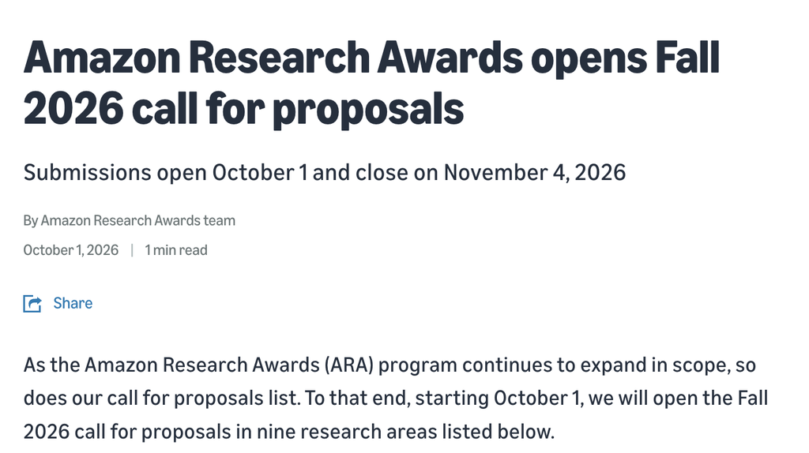

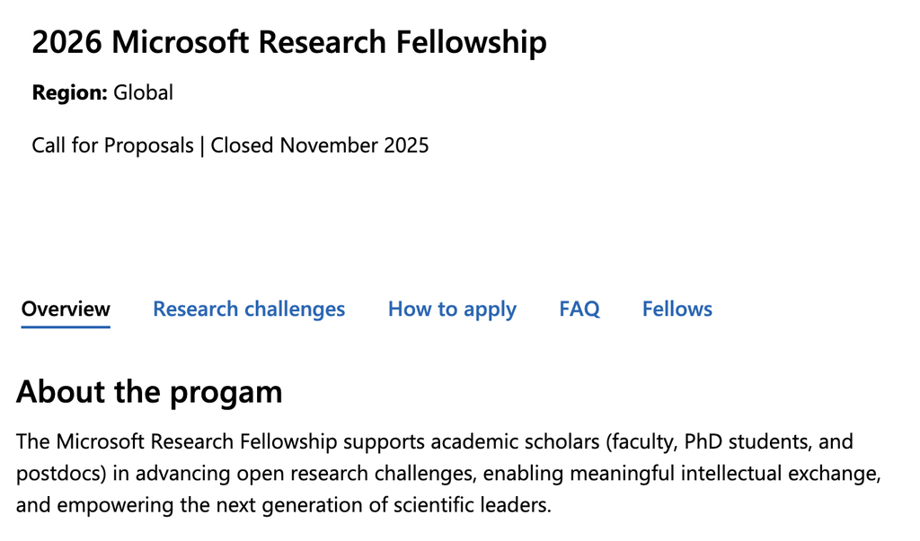

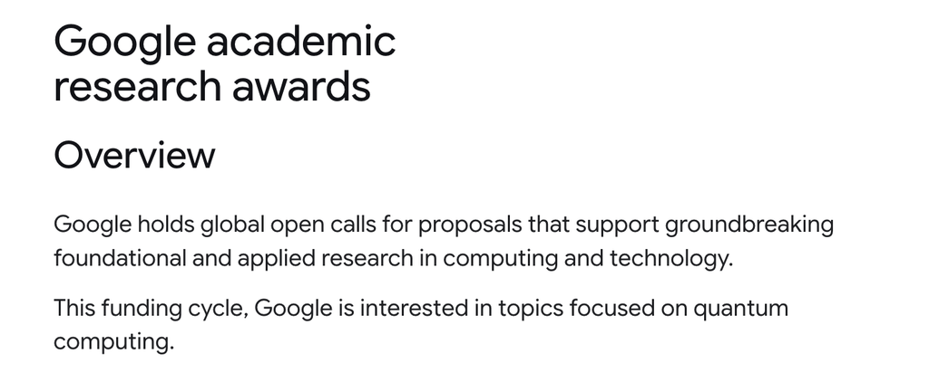

ಧನ್ಯವಾದಗಳು · Thank you

samyak@alumni.stanford.edu · linkedin.com/in/rsamyak

These slides

[figure not shown]

Speed vs accuracy

How many hypotheses

Measuring the methods

$\{\text{questions industry cares about}\} \cap \{\text{academic expertise needed to solve them}\} \neq \emptyset$ !

## References

- Isaiah Andrews and Maximilian Kasy, 2019. *American Economic Review*.
- Kenneth Arrow, David Blackwell, and Meyer Girshick, 1949. *Econometrica*.
- Eduardo Azevedo, Alex Deng, José Luis Montiel Olea, Justin Rao, and E. Glen Weyl, 2020. *Journal of Political Economy*. (Fat tails.)
- Yoav Benjamini and Yosef Hochberg, 1995. *JRSS B*.
- James Berger, 1985. *Statistical Decision Theory and Bayesian Analysis*. Springer. ($\Gamma$-minimax.)
- Roger Berger, 1982. Multiparameter hypothesis testing and acceptance sampling. *Technometrics*.
- Frank Bretz, Willi Maurer, Werner Brannath, and Martin Posch, 2009. *Statistics in Medicine*.
- Herman Chernoff, 1961. *Fourth Berkeley Symposium*.
- Herman Chernoff, 1965. Sequential Test for the Mean of a Normal Distribution III (Small $t$). *Annals of Mathematical Statistics*. (Best SPRT against Bayes, for one prior.)
- Thomas Crook, Brian Frasca, Ron Kohavi, and Roger Longbotham, 2009. Seven pitfalls to avoid when running controlled experiments on the web. KDD.
- George Dantzig, 1957. Discrete-variable extremum problems. *Operations Research*.
- Jacqueline Doremus, Joel Persson, Brian St. Thomas, Carlos A. Flores, Sebastian Ankargren, Mårten Schultzberg, and Kyle Kretschman, 2026. Return-aware platform experimentation: new directions for research. *Marketing Letters*.
- Bradley Efron, 2016. Empirical Bayes deconvolution estimates. *Biometrika*.
- Ignacio Esponda and Demian Pouzo, 2016. Berk–Nash equilibrium: a framework for modeling agents with misspecified models. *Econometrica*.

## References

- Aleksander Fabijan et al., 2019. Diagnosing sample ratio mismatch in online controlled experiments. KDD.
- Elea McDonnell Feit and Ron Berman, 2019. Test & Roll: Profit-Maximizing A/B Tests. *Marketing Science*. (One idea.)
- Ronald Fisher, 1935. *The Design of Experiments*.
- Dean Foster and Robert Stine, 2008. *JRSS B*.
- Somit Gupta et al., 2018. The Anatomy of a Large-Scale Online Experimentation Platform. ICSA.
- Sture Holm, 1979. *Scandinavian Journal of Statistics*.
- Steven Howard, Aaditya Ramdas, Jon McAuliffe, and Jasjeet Sekhon, 2021. Time-uniform, nonparametric, nonasymptotic confidence sequences. *Annals of Statistics*.
- Peter Huber, 1964. Robust estimation of a location parameter. *Annals of Mathematical Statistics*.
- Adel Javanmard and Andrea Montanari, 2018. *Annals of Statistics*.
- Ramesh Johari, Pete Koomen, Leonid Pekelis, and David Walsh, 2022. Always Valid Inference: Continuous Monitoring of A/B Tests. *Operations Research*.
- Ron Kohavi, Alex Deng, Brian Frasca, Toby Walker, Ya Xu, and Nils Pohlmann, 2013. Online controlled experiments at large scale. KDD.
- Ron Kohavi, Alex Deng, Roger Longbotham, and Ya Xu, 2014. Seven rules of thumb for web site experimenters. KDD.
- Ron Kohavi and Stefan Thomke, 2017. The Surprising Power of Online Experiments. *Harvard Business Review*.

## References

- Ron Kohavi, Diane Tang, and Ya Xu, 2020. *Trustworthy Online Controlled Experiments*.
- Ron Kohavi, Alex Deng, and Lukas Vermeer, 2022. A/B testing intuition busters. KDD.
- Nicholas Larsen et al., 2024. *The American Statistician*. (Worked example.)
- Robert Lehr, 1992. Sixteen S-squared over D-squared: a relation for crude sample size estimates. *Statistics in Medicine*.
- Michael Lindon and Alan Malek, 2022. Anytime-valid inference for multinomial count data. NeurIPS. (An anytime-valid sample-ratio test.)
- C. H. Bryan Liu, Ângelo Cardoso, Paul Couturier, and Emma McCoy, 2021. Datasets for online controlled experiments. NeurIPS Datasets and Benchmarks.
- Charles Manski, 2003. *Partial Identification of Probability Distributions*. Springer.
- J. Nathan Matias, Kevin Munger, Marianne Aubin Le Quere, and Charles Ebersole, 2021, corrected 2024. The Upworthy Research Archive, a time series of 32,487 experiments in U.S. media. *Scientific Data*.
- Kari Lock Morgan and Donald Rubin, 2012. Rerandomization to improve covariate balance in experiments. *Annals of Statistics*.
- Jerzy Neyman, 1923. On the application of probability theory to agricultural experiments. Essay on principles.
- Jerzy Neyman and Egon Pearson, 1933.
- Howard Raiffa and Robert Schlaifer, 1961. *Applied Statistical Decision Theory*.
- Herbert Robbins, 1956. An empirical Bayes approach to statistics. *Third Berkeley Symposium*.
- Donald Rubin, 1974. Estimating causal effects of treatments in randomized and nonrandomized studies. *Journal of Educational Psychology*.
- Sven Schmit, Virag Shah, and Ramesh Johari, 2019. Optimal testing in the experiment-rich regime. AISTATS.

## References

- David Schott, 2018. Double-bucketing in A/B Testing. Etsy Code as Craft.
- Mårten Schultzberg, Sebastian Ankargren, and Mattias Frånberg, 2026. Risk-aware product decisions in A/B tests with multiple metrics. *Journal of Statistical Planning and Inference*.
- Mårten Schultzberg and Mattias Frånberg, 2026. arXiv. (Priors that fail to calibrate.)
- Charles Stein, 1956. Inadmissibility of the usual estimator for the mean of a multivariate normal distribution. *Third Berkeley Symposium*.
- Chris Stucchio, 2015. VWO SmartStats white paper.
- Timothy Sudijono, Simon Ejdemyr, Apoorva Lal, and Martin Tingley, 2025. Optimizing returns from experimentation programs. EC ’25.
- Mack Sweeney, Matthew van Adelsberg, Kathryn Laskey, and Carlotta Domeniconi, 2020. ICDM.
- Diane Tang, Ashish Agarwal, Deirdre O’Brien, and Mike Meyer, 2010. KDD.
- Vendor documentation, checked October 2026.
- Abraham Wald, 1945.
- Abraham Wald and Jacob Wolfowitz, 1948. *Annals of Mathematical Statistics*.
- Zhenyu Zhao and Eva Feng, 2017. Building an intelligent experimentation platform with Uber Engineering. Uber Engineering blog.

## Appendix: the same figure, on log scales

[figure not shown]

Computed, not schematic: one knob traces a curve; two knobs fill a region, whose lower edge is the best tuning. Fixed horizon has sample size and level: the grey edge is the sign rule, and the band reaches the 5% level. SPRT is one knob; mixture SPRT and expected loss show lower edges. $\theta\sim N(0,\gamma^2)$; $S$ is in units of $\sigma^2/\gamma^2$, and $R$ in units of $\gamma$; log scales.